# R Notebook

```r
# Read anndata file
library(Seurat)
library(Matrix)
white_00 <- ReadH5AD(file ="/home/rstudio/time-series/adata/white_00.h5ad")
```

[output not shown]

```r
white_05 <- Read10X(data.dir = "/home/rstudio/time-series/umi-counts/white_05_inex")
white_10 <- ReadH5AD(file ="/home/rstudio/time-series/adata/white_10.h5ad")
```

[output not shown]

```r
white_15 <- ReadH5AD(file ="/home/rstudio/time-series/adata/white_15.h5ad")
```

[output not shown]

```r
white_20 <- ReadH5AD(file ="/home/rstudio/time-series/adata/white_20.h5ad")
```

[output not shown]

```r
bwhite_00=read.table(file = "/home/rstudio/time-series/files/white_00/barcodes.txt",header = FALSE,sep = "\n")
bwhite_05=read.table(file = "/home/rstudio/time-series/files/white_05/barcodes.txt",header = FALSE,sep = "\n")
bwhite_10=read.table(file = "/home/rstudio/time-series/files/white_10/barcodes.txt",header = FALSE,sep = "\n")
bwhite_15=read.table(file = "/home/rstudio/time-series/files/white_15/barcodes.txt",header = FALSE,sep = "\n")
bwhite_20=read.table(file = "/home/rstudio/time-series/files/white_20/barcodes.txt",header = FALSE,sep = "\n")

white_00=subset(white_00,cells=bwhite_00$V1)
white_05=white_05[,bwhite_05$V1]
white_05=CreateSeuratObject(white_05)
white_10=subset(white_10,cells=bwhite_10$V1)
white_15=subset(white_15,cells=bwhite_15$V1)
white_20=subset(white_20,cells=bwhite_20$V1)

s_white=merge(white_00, y = c(white_05, white_10, white_15, white_20), add.cell.ids = seq(0,20,5))
s_white$batch.indices=as.factor(unlist(strsplit(x = colnames(s_white),split = "_"))[c(TRUE,FALSE)])
Idents(s_white)="batch.indices"
#s_white@meta.data$nCount_RNA=colSums(s_white@assays$RNA@counts)
#s_white@meta.data$nFeatures_RNA=colSums(s_white@assays$RNA@counts>0)

# Add latent space
l_white <- read.csv("/home/rstudio/time-series/latent_space/white_all.csv", row.names=1)
l_white=as.matrix(l_white)
rownames(l_white)=rownames(s_white@meta.data)
s_white[["scVI"]] <- CreateDimReducObject(embeddings =l_white,key = "scVI_")
```

```
No assay specified, setting assay as RNA by default.
```

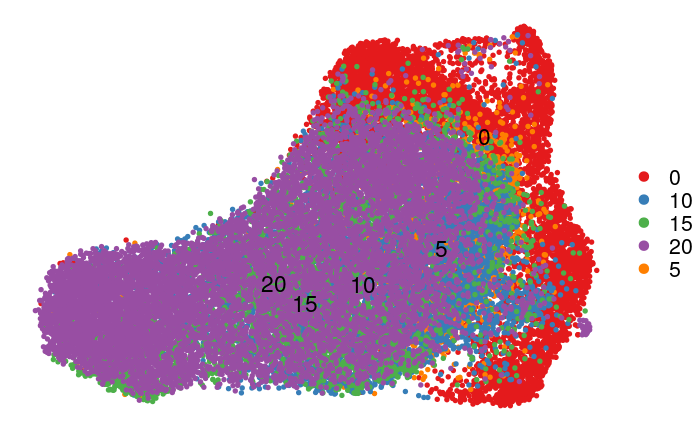

```r
# Generate UMAP
s_white=RunUMAP(s_white,reduction="scVI",dims = 1:10)
library(RColorBrewer)
library(ggplot2)
UMAPPlot(s_white,label=TRUE,label.size=6,cols=brewer.pal(n = 5,"Set1"),pt.size=1.25)+theme_void(base_size = 20)
ggsave("/home/rstudio/time-series/figures/white_integration/batch.eps",dpi=300, dev='eps', height=6, width=8, units="in")
```

```r
# Normalize data for visualization
s_white=NormalizeData(s_white)
```

Mitochondrial genes are in the list of most variable genes. Plot the percent MT content to check if it is enriched in adipocytes Ans: No. MT content is not high in cluster enriched for ADIPOQ expression. It is rather placed in the middle right section of the differentiating preadipocytes blob One strategy could be to remove cells with MT content greater than the mean MT content in adipocytes, since these cells are expected to have elevated mitochondrial activity I also want to understand what days are contributing the most to MT content being high. Ans: Day 15 and Day 20. See the section below

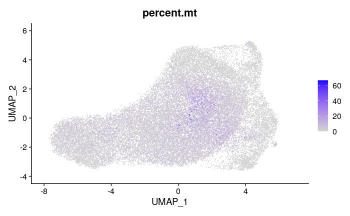

```r
s_white[["percent.mt"]] <- PercentageFeatureSet(s_white, pattern = "^MT-")
FeaturePlot(s_white,"percent.mt")
```

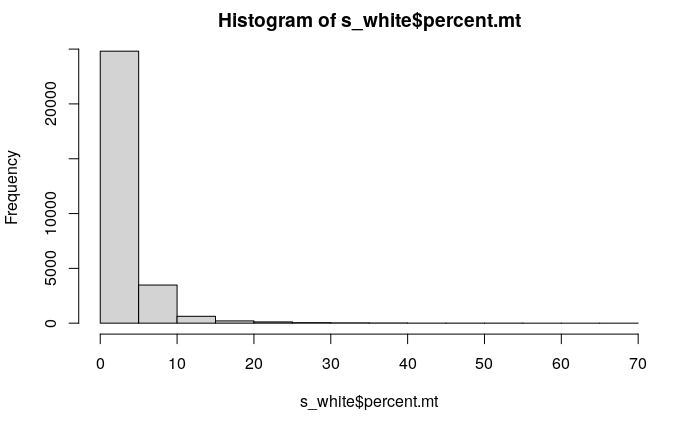

```r
hist(s_white$percent.mt)
```

# For MT content between 10-30%, most of the barcodes are from Day 20, and for MT content between 30% and 70%, most barcodes are from Day 15 and Day 20, and these barcodes do not express ADIPOQ.

```r
mt_content=as.data.frame(s_white$percent.mt)
colnames(mt_content)="percent.mt"
mt_content$barcodes=rownames(mt_content)
mt_content=mt_content[order(mt_content$percent.mt,decreasing = FALSE),]
mt_content$bin=cut(mt_content$percent.mt,breaks=c(-Inf,seq(10, 100, 10)),labels = FALSE)
mt_content$batch.indices=s_white@meta.data[mt_content$barcodes,"batch.indices"]
round(table(mt_content$bin,mt_content$batch.indices)/rowSums(table(mt_content$bin,mt_content$batch.indices))*100,1)
```

```
       0   10   15   20    5
  1 24.2 20.7 14.3 30.9  9.9
  2  0.0 15.8 12.2 60.8 11.2
  3  0.0  2.4 20.6 77.1  0.0
  4  0.0  0.0 40.7 59.3  0.0
  5  0.0  0.0 52.6 47.4  0.0
  6  0.0  0.0 66.7 33.3  0.0
  7  0.0  0.0 75.0 25.0  0.0
```

# If I only keep barcodes with < 10% MT content, assuming that mean MT content in adipocyte cluster is < 10%, what percent of barcodes do I loose from each day.

```r
apply(table(mt_content$bin,mt_content$batch.indices),2,function(x){round(x/sum(x)*100,1)})
```

```
      0   10   15   20    5
  1 100 97.7 95.8 92.7 96.7
  2   0  2.2  2.4  5.4  3.3
  3   0  0.1  0.8  1.4  0.0
  4   0  0.0  0.5  0.3  0.0
  5   0  0.0  0.2  0.1  0.0
  6   0  0.0  0.1  0.0  0.0
  7   0  0.0  0.1  0.0  0.0
```

What are the sub-clusters on Day 0? Can DE help me identify these sub-clusters?

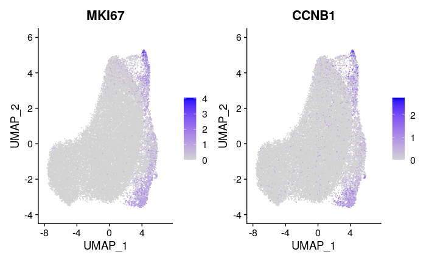

```r
FeaturePlot(s_white,c("MKI67","CCNB1"))
```

```r
s_white=FindNeighbors(s_white,reduction="scVI",graph.name="RNA_snn_scVI",dims=1:10)
s_white=FindClusters(s_white,resolution = 0.7,graph.name = "RNA_snn_scVI", verbose = FALSE)
```

resolution = 0.7 gives a cluster for the three sub-clusters on day-0. It also identifies a few other clusters such as cluster 5, 0, 1 whose identity remains to be established the first question is what are cluster 6 and 4?

[figure not shown]

```r
round(table(s_white$RNA_snn_scVI_res.0.7,s_white$batch.indices)/rowSums(table(s_white$RNA_snn_scVI_res.0.7,s_white$batch.indices))*100,1)
```

```
       0   10   15   20    5
  0  2.5 34.7  6.6 25.5 30.8
  1  1.4 32.2 28.6 33.6  4.1
  2  0.1 11.2 19.6 68.2  0.9
  3 71.6  4.3  6.8 13.9  3.5
  4 80.9  7.6  6.5  3.0  2.0
  5  4.2 22.8 15.5 47.0 10.6
  6 93.2  1.6  0.6  2.2  2.4
```

```r
apply(table(s_white$RNA_snn_scVI_res.0.7,s_white$batch.indices),2,function(x){round(x/sum(x)*100,1)})
```

```
       0   10   15   20    5
  0  2.5 39.6 10.7 18.5 73.0
  1  1.3 34.6 43.8 23.0  9.2
  2  0.1 10.3 25.8 40.0  1.7
  3 45.1  3.1  6.9  6.3  5.2
  4 35.5  3.8  4.7  1.0  2.1
  5  1.3  8.3  8.1 10.9  8.1
  6 14.2  0.3  0.1  0.2  0.9
```

[figure not shown]

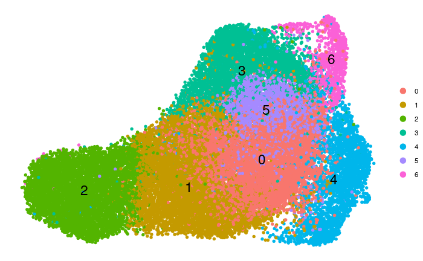

```r
UMAPPlot(s_white,label=TRUE,label.size=6,pt.size=1.25)+theme_void()
```

```r
i_5=FindMarkers(object = s_white,ident.1 = 5,logfc.threshold = 1,only.pos = TRUE)
```

[output not shown]

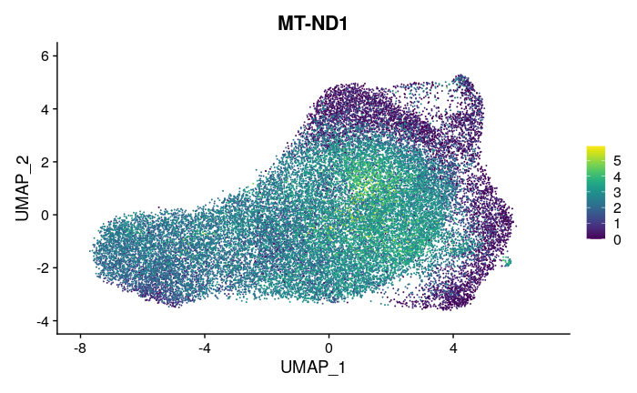

```r
library(viridis)
FeaturePlot(s_white,"MT-ND1")+scale_color_viridis()
```

What is cluster 6? Have done this analysis in white_00.Rmd Identify barcodes in day 0 seurat object

```r
barcodes.cluster.6=WhichCells(s_white,idents = 6)
barcodes.cluster.6=barcodes.cluster.6[substr(barcodes.cluster.6,start = 1,stop = 1)==0]
barcodes.cluster.6=substr(barcodes.cluster.6,start = 3,stop = 20)

barcodes.cluster.3=WhichCells(s_white,idents = 3)
barcodes.cluster.3=barcodes.cluster.3[substr(barcodes.cluster.3,start = 1,stop = 1)==0]
barcodes.cluster.3=substr(barcodes.cluster.3,start = 3,stop = 20)

barcodes.cluster.4=WhichCells(s_white,idents = 4)
barcodes.cluster.4=barcodes.cluster.4[substr(barcodes.cluster.4,start = 1,stop = 1)==0]
barcodes.cluster.4=substr(barcodes.cluster.4,start = 3,stop = 20)
```

[figure not shown]

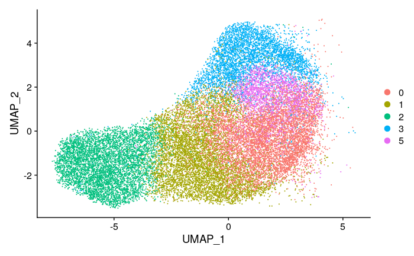

```r
s_white_subset=subset(s_white,cells = barcodes.to.keep)
UMAPPlot(s_white_subset)
```

```r
save(s_white_subset,file = "/home/rstudio/time-series/Rdata/seurat_white_adipo_trajectory.RData")
```

[figure not shown]

```r
x=FindMarkers(s_white,ident.1 = 4,ident.2 = 3,logfc.threshold = 1,only.pos = T)
y=FindMarkers(s_white,ident.1 = 4,ident.2 = 0,logfc.threshold = 1,only.pos = T)
FeaturePlot(s_white,features = rownames(x)[order(x$avg_logFC,decreasing = T)][1:4])
FeaturePlot(s_white,features = rownames(y)[order(y$avg_logFC,decreasing = T)][1:4])
```

[output not shown]